# Understanding Tucker Carlson’s Audience

Beliefs, Attitudes, and the Effects of an AI-Delivered Factual Intervention — Connect Sample (Pilot)

Published

February 18, 2026

**WarningPilot Data — Treat All Results as Preliminary**

This report covers the **Connect panel sample**: **91 completed responses** out of 106 total, collected on February 17, 2026. Results should be treated as exploratory pending full-scale data collection.

**NoteKey Difference from the PrimePanels Sample**

The Connect sample was recruited through CloudResearch’s Connect platform, which draws from a broader, more politically diverse pool than PrimePanels. Panel-provided demographic information (age, gender, race, income, education, party) is used where available and supplemented by in-survey responses. **Post-treatment batteries use question numbers Q17–Q21** (versus Q18–Q22 in PrimePanels).

# 1 Study Overview

This study examines the beliefs, attitudes, and media consumption patterns of Tucker Carlson viewers using an AI-delivered factual intervention. The survey flow mirrors the PrimePanels study:

1. **Pre-treatment measures** — media engagement, conspiracy beliefs, foreign policy attitudes, and feelings toward Israel (Q1–Q12).
2. **AI-delivered conversation** — structured factual dialogue about Israel-related topics (experimental manipulation).
3. **Post-treatment measures** — same attitude batteries administered again (Q17–Q21), plus open-ended reflections (Q22–Q23).

| Domain | Pre | Post |
| --- | --- | --- |
| Carlson credibility | Q8 | Q17 |
| Foreign policy views | Q9 | Q18 |
| Feelings toward Israel / Jewish people | Q10 | Q19 |
| Carlson’s Israel commentary | Q11 | Q20 |
| Israel policy positions | Q12 | Q21 |

# 2 Sample Characteristics

## 2.1 Age Distribution

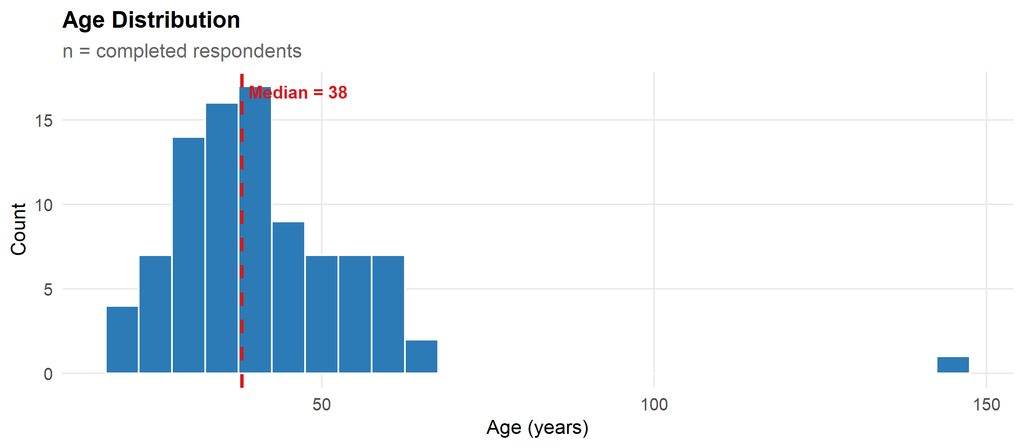

Figure 1: Age distribution of Connect respondents (panel-provided)

## 2.2 Demographics Overview

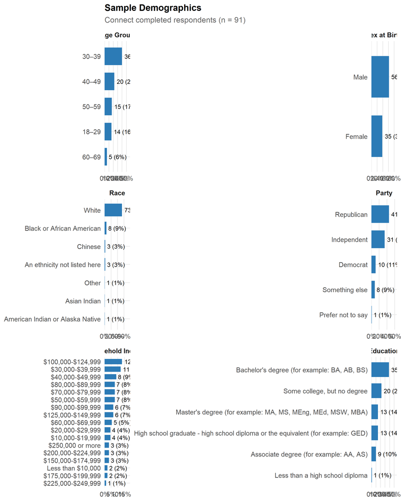

Figure 2: Demographic profile of Connect completed respondents

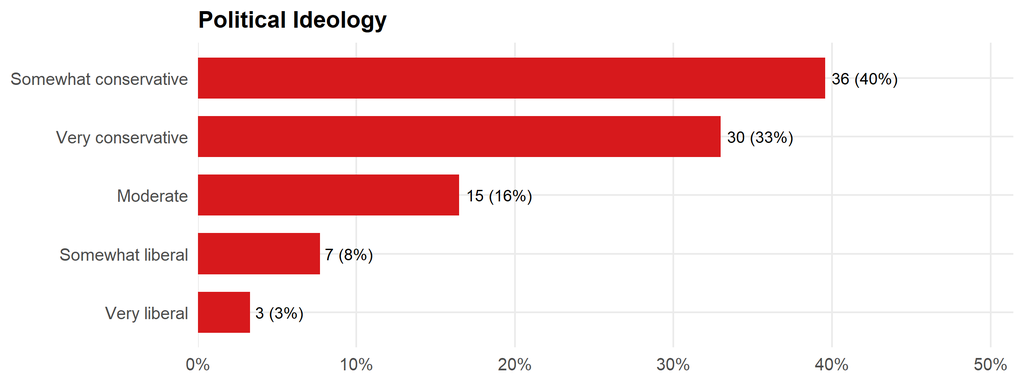

Figure 3: Self-reported political ideology (survey-asked)

Table 1: Summary of sample demographics (Connect)

| Characteristic | Top Category / Summary |
| --- | --- |
| **N completed** | 91 |
| **Age** | Median = 38 yrs (range: 18–143) |
| **Sex at Birth** | Male — 56 (62%) |
| **Race** | White — 73 (81%) |
| **Political Party** (panel) | Republican — 41 (45%) |
| **Household Income** | $100,000-$124,999 — 12 (13%) |
| **Education** | Bachelor's degree (for example: BA, AB, BS) — 35 (38%) |

## 2.3 Relationship with Tucker Carlson’s Content

The Connect platform pre-screened participants using their existing Tucker Carlson viewership habits.

Table 2: Tucker Carlson content relationship (pre-screening variable)

| Relationship with Tucker Carlson Content | n | % |
| --- | --- | --- |
| I listen to or watch his content occasionally and generally agree with his views | 53 | 58% |
| I listen to or watch his content regularly and generally agree with his views | 38 | 42% |

# 3 Tucker Carlson Engagement

## 3.1 Viewing Frequency and Israel Familiarity

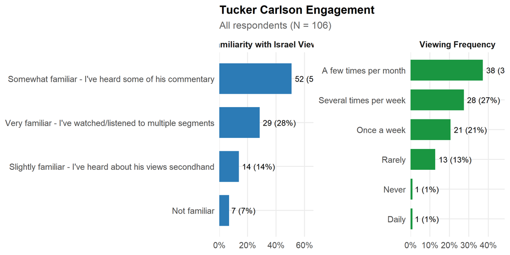

Figure 4: Viewing frequency and familiarity with Carlson’s Israel commentary

## 3.2 Commentator Credibility Ratings

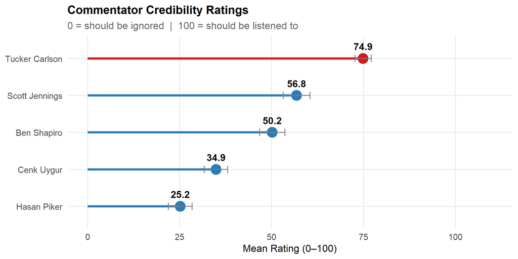

Figure 5: Mean ‘should be listened to’ ratings (0 = ignored, 100 = listened to)

## 3.3 Why They Watch Tucker Carlson

Table 3: Open-ended responses: Why do you watch or listen to Tucker Carlson? (selected)

| Participant Response |
| --- |
| As background noise |
| I'm interested in some of his commentary because I identify more with conservative views. |
| He supports M.A.G.A |
| he tries to be as objective as possible |
| i agree with that he says and i agree with his views on a lot of topics |
| i value his direct conservative perspective on issues such as immigration and foreign policy, also how he challenges various societal narratives |
| His analysis on issues is broad and open minded. |
| i love his perspective of societal issues such as US foreign aid policy. he tends to have a unique view especially in addressing issues that are often avoid by many since they are unpopular opinion... |
| I watch many of the political commentators for opinions and entertainment |
| It's an interesting show |
| Because he speaks candidly about issues affecting the country as a whole as well as he speaks to ordinary concerns of regular working class American population. |
| I find his views and discussion with his guests to be interesting. |

# 4 Baseline Beliefs and Attitudes

## 4.1 Conspiracy and Fringe Beliefs

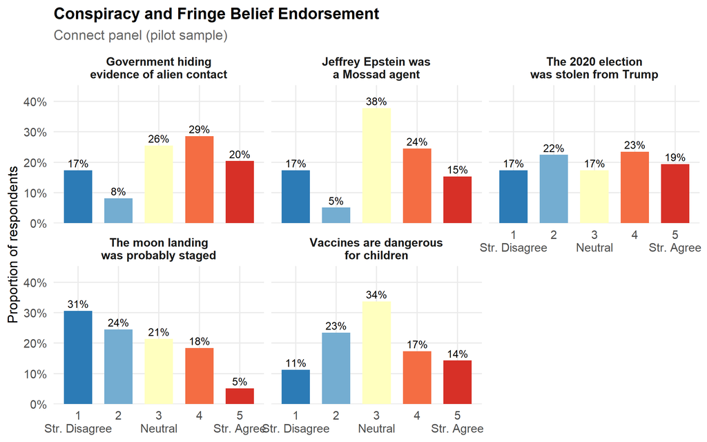

Figure 6: Distribution of conspiracy/fringe belief endorsement (1–5 scale)

## 4.2 Foreign Policy Views (Pre-Treatment)

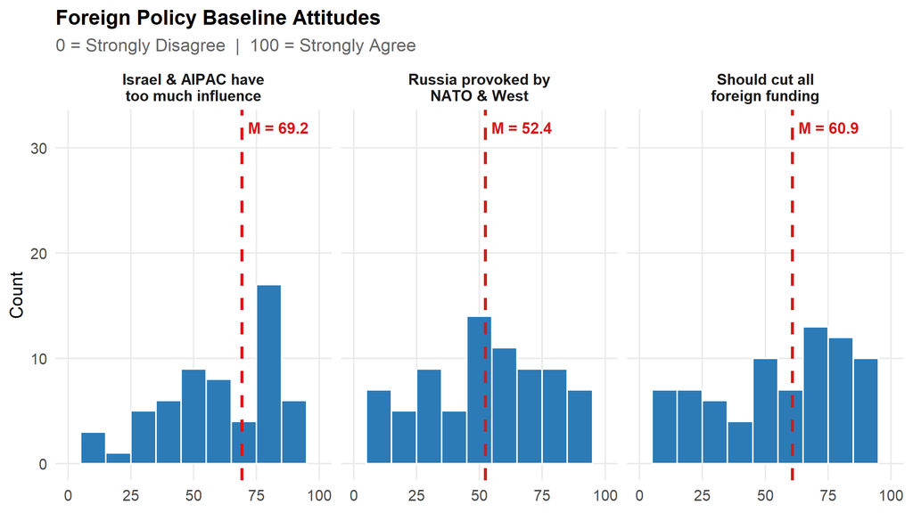

Figure 7: Baseline foreign policy attitude distributions (0–100 slider)

## 4.3 Feelings Toward Israel and Jewish People (Pre-Treatment)

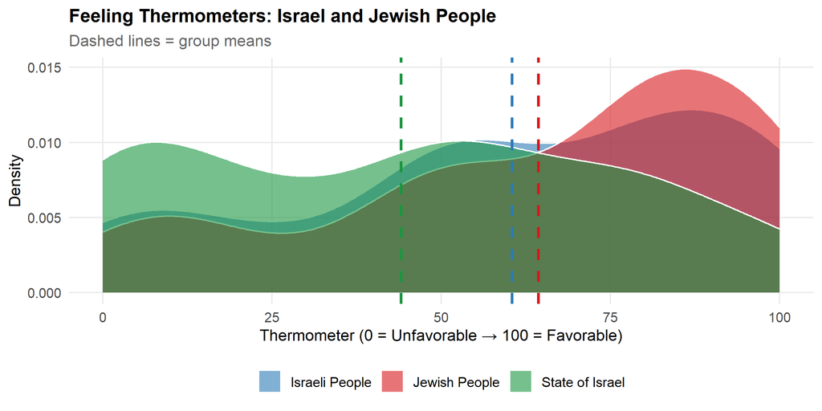

Figure 8: Baseline feeling thermometer ratings (0 = Extremely Unfavorable, 100 = Extremely Favorable)

Feeling thermometer summary statistics (pre-treatment)

| item | M | SD | Md | N |
| --- | --- | --- | --- | --- |
| Israeli People | 60.5 | 31.8 | 64 | 97 |
| Jewish People | 64.4 | 30.9 | 77 | 97 |
| State of Israel | 44.1 | 32.1 | 50 | 97 |

# 5 Experimental Conditions

| Note |
| --- |
| Block randomizer column not found — condition information unavailable. |

# 6 Pre- to Post-Treatment Attitude Changes

> **Note:** In the Connect survey, post-treatment batteries use question numbers Q17–Q21 (one lower than in the PrimePanels survey).

All scales are 0–100.

## 6.1 Credibility of Tucker Carlson

Table 5: Tucker Carlson credibility: pre (Q8) vs. post (Q17)

Tucker Carlson Credibility (0–100 sliders)

| Item | n | Pre M | Post M | Δ | d | p |
| --- | --- | --- | --- | --- | --- | --- |
| Trusts his foreign policy analysis | 91 | 69.2 | 69.2 | 0 | 0.00 | 0.995 |
| He almost always gets the facts right | 91 | 68.1 | 66.4 | -1.7 | -0.11 | 0.304 |
| His predictions are usually accurate | 91 | 64.4 | 65.2 | +0.8 | 0.05 | 0.614 |
| Covers important topics others ignore | 91 | 83.1 | 81.5 | -1.6 | -0.11 | 0.276 |
| Effectively challenges mainstream narratives | 91 | 83.4 | 82.4 | -1 | -0.08 | 0.451 |
| He often gets things wrong | 91 | 31.7 | 33.2 | +1.5 | 0.08 | 0.452 |

All scales: 0–100. d = Cohen's d for paired differences. † p<.10, * p<.05, ** p<.01, *** p<.001.

## 6.2 Foreign Policy Views

Table 6: Foreign policy views: pre (Q9) vs. post (Q18)

Foreign Policy Views (0–100 sliders)

| Item | n | Pre M | Post M | Δ | d | p |
| --- | --- | --- | --- | --- | --- | --- |
| Russia was provoked by NATO and the West | 91 | 52.5 | 55.6 | +3.1 | 0.18 | 0.094 † |
| Israel and AIPAC have too much influence over America | 91 | 69.0 | 71.3 | +2.3 | 0.17 | 0.099 † |
| We should cut all funding to foreign countries | 91 | 61.0 | 62.1 | +1.1 | 0.07 | 0.489 |

All scales: 0–100. d = Cohen's d for paired differences. † p<.10, * p<.05, ** p<.01, *** p<.001.

## 6.3 Feelings Toward Israel and Jewish People

Table 7: Feeling thermometers: pre (Q10) vs. post (Q19)

Feeling Thermometers (0–100)

| Item | n | Pre M | Post M | Δ | d | p |
| --- | --- | --- | --- | --- | --- | --- |
| Israeli people | 91 | 61.1 | 60.5 | -0.7 | -0.07 | 0.518 |
| Jewish people | 91 | 65.2 | 64.2 | -1.1 | -0.11 | 0.294 |
| The State of Israel | 91 | 45.0 | 44.1 | -0.8 | -0.08 | 0.431 |

All scales: 0–100. d = Cohen's d for paired differences. † p<.10, * p<.05, ** p<.01, *** p<.001.

## 6.4 Tucker Carlson’s Israel Commentary

Table 8: Perceptions of Tucker Carlson’s Israel commentary: pre (Q11) vs. post (Q20)

Tucker Carlson's Israel Commentary (0–100 sliders)

| Item | n | Pre M | Post M | Δ | d | p |
| --- | --- | --- | --- | --- | --- | --- |
| His commentary on Israel is accurate and fair | 91 | 69.7 | 68.8 | -0.8 | -0.04 | 0.685 |
| He asks the right questions about America's relationship with Israel | 91 | 76.0 | 76.0 | 0 | 0.00 | 0.985 |
| He is too critical of Israel | 91 | 30.6 | 33.4 | +2.8 | 0.16 | 0.131 |
| He understands the Middle East better than most commentators | 91 | 68.4 | 69.3 | +0.9 | 0.05 | 0.626 |

All scales: 0–100. d = Cohen's d for paired differences. † p<.10, * p<.05, ** p<.01, *** p<.001.

## 6.5 Israel Policy Positions

Table 9: Israel policy views: pre (Q12) vs. post (Q21)

Israel Policy Views (0–100 sliders)

| Item | n | Pre M | Post M | Δ | d | p |
| --- | --- | --- | --- | --- | --- | --- |
| The U.S.–Israel relationship benefits the United States | 91 | 43.1 | 43.9 | +0.9 | 0.05 | 0.642 |
| Israel has a legitimate right to exist as a Jewish state | 91 | 61.7 | 60.7 | -1 | -0.09 | 0.387 |
| Israel generally acts morally in its self-defense | 91 | 42.9 | 45.9 | +3 | 0.17 | 0.099 † |
| The U.S. should reduce military aid to Israel | 91 | 69.9 | 70.7 | +0.8 | 0.05 | 0.649 |

All scales: 0–100. d = Cohen's d for paired differences. † p<.10, * p<.05, ** p<.01, *** p<.001.

## 6.6 Summary: All Pre/Post Changes

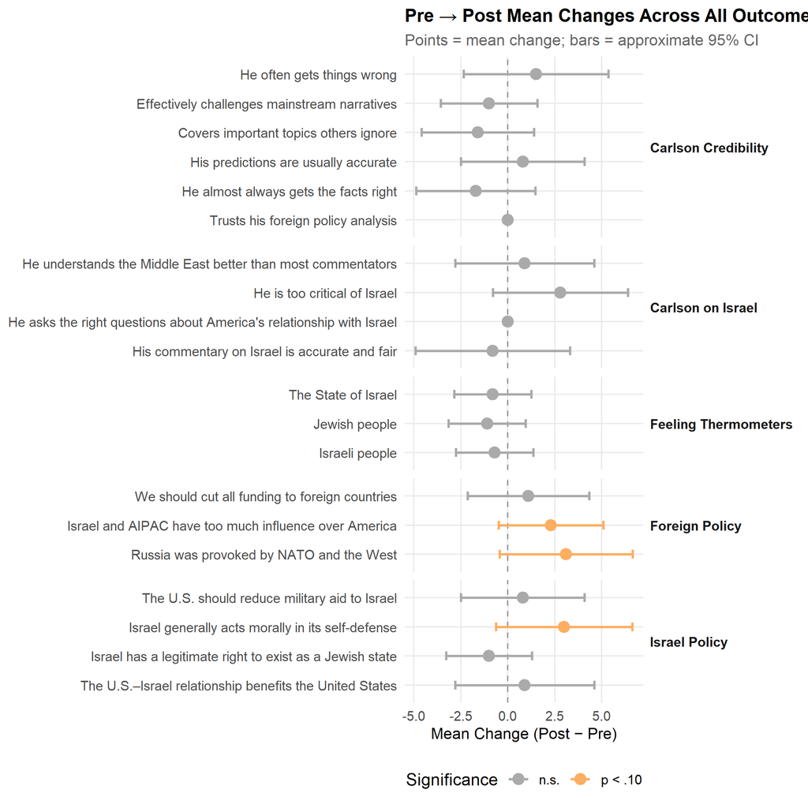

Figure 9: All pre/post mean changes with approximate 95% confidence intervals. Red = significant (p < .05), orange = marginal (p < .10), grey = non-significant.

# 7 Audience Segmentation

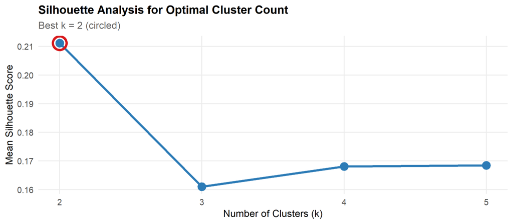

Figure 10: Silhouette scores by number of clusters (higher = better fit)

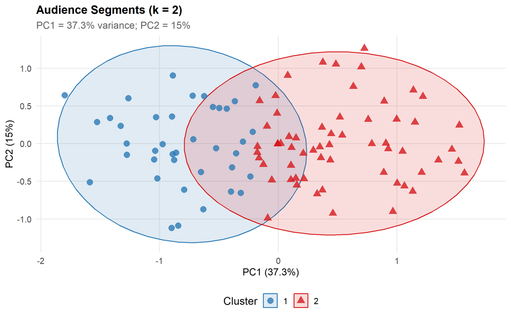

Figure 11: Audience segments visualized via PCA (first two principal components)

Table 10: Cluster mean profiles on key attitude dimensions

| n | Item | Cluster 1 | Cluster 2 |
| --- | --- | --- | --- |
| **Conspiracy Beliefs** |  |  |  |
| 39 | Vaccines dangerous (1–5) | 2.7 | NA |
| 39 | Moon landing staged (1–5) | 2.0 | NA |
| 39 | Epstein/Mossad (1–5) | 2.5 | NA |
| 39 | Alien contact hidden (1–5) | 2.7 | NA |
| 39 | 2020 election stolen (1–5) | 3.2 | NA |
| **Foreign Policy** |  |  |  |
| 39 | Russia provoked by NATO (0–100) | 40.7 | NA |
| 39 | Israel/AIPAC too influential (0–100) | 39.8 | NA |
| 39 | Cut all foreign funding (0–100) | 49.7 | NA |
| **Feeling Thermometers** |  |  |  |
| 39 | Israeli people thermometer (0–100) | 81.7 | NA |
| 39 | Jewish people thermometer (0–100) | 82.7 | NA |
| 39 | State of Israel thermometer (0–100) | 74.3 | NA |
| **Carlson on Israel** |  |  |  |
| 39 | Carlson Israel commentary accurate (0–100) | 62.4 | NA |
| 39 | Asks right questions on US-Israel (0–100) | 70.7 | NA |
| 39 | Too critical of Israel (0–100) | 48.2 | NA |
| 39 | Understands Middle East (0–100) | 66.5 | NA |
| **Israel Policy** |  |  |  |
| 39 | US-Israel benefits US (0–100) | 69.6 | NA |
| 39 | Israel right to exist (0–100) | 85.6 | NA |
| 39 | Israel acts morally (0–100) | 71.5 | NA |
| 39 | Reduce military aid (0–100) | 40.2 | NA |
| 67 | Vaccines dangerous (1–5) | NA | 3.2 |
| 67 | Moon landing staged (1–5) | NA | 2.6 |
| 67 | Epstein/Mossad (1–5) | NA | 3.5 |
| 67 | Alien contact hidden (1–5) | NA | 3.6 |
| 67 | 2020 election stolen (1–5) | NA | 3.0 |
| 67 | Russia provoked by NATO (0–100) | NA | 59.3 |
| 67 | Israel/AIPAC too influential (0–100) | NA | 87.4 |
| 67 | Cut all foreign funding (0–100) | NA | 68.3 |
| 67 | Israeli people thermometer (0–100) | NA | 48.7 |
| 67 | Jewish people thermometer (0–100) | NA | 55.5 |
| 67 | State of Israel thermometer (0–100) | NA | 27.4 |
| 67 | Carlson Israel commentary accurate (0–100) | NA | 73.3 |
| 67 | Asks right questions on US-Israel (0–100) | NA | 79.0 |
| 67 | Too critical of Israel (0–100) | NA | 20.8 |
| 67 | Understands Middle East (0–100) | NA | 69.6 |
| 67 | US-Israel benefits US (0–100) | NA | 29.0 |
| 67 | Israel right to exist (0–100) | NA | 48.4 |
| 67 | Israel acts morally (0–100) | NA | 27.3 |
| 67 | Reduce military aid (0–100) | NA | 86.9 |

# 8 Qualitative Themes

## 8.1 Has Tucker Changed Their Views on Israel?

Table 11: Has Tucker Carlson’s commentary influenced your views on Israel? (Q13)

| Response | n | % |
| --- | --- | --- |
| I'm not sure/Not applicable | 4 | 4% |
| No impact on my views | 43 | 44% |
| Reinforced views I already held | 29 | 30% |
| Yes, significantly changed my views | 7 | 7% |
| Yes, somewhat influenced my views | 14 | 14% |

## 8.2 What Tucker Gets Right About Israel

Table 12: Open-ended: What do you think Tucker Carlson gets right about Israel? (selected)

| Participant Response |
| --- |
| His views on trade policies, leadership, and important roles. Also how our president views their ideals |
| I know that he is correct that Israel has too much influence over the entire US government on both sides. |
| I think his view on supporting Israel has change since the war in Gaza. |
| that they have America by the balls and that they have and are continuing to commit a holocaust in Gaza |
| that they control the american government |
| he question issues such as US foreign aid allocation in such nations such as Israel. like querry how this aligns with the US interest as a nation |
| We are wasting our resources to help them fight a war that does not concern us at all |
| tucker points out that the spendings by US on israel security should have a payoff. there should also be trasparency on how the money is spent to avoid taxepayers money being embezzled and creating wa… |
| That Israel has to much control over various nations. |
| I don't know his views on Israel |
| I don't think his views are very unique. He's basically just following public opinion from over a year ago. I guess he's right to listen to people. |
| He understands that we don't need to keep sending weapons there if it is not in our national interest. He gets that we need that taxpayer money to be spent here at home in the USA |

## 8.3 Post-Conversation Reflections

Table 13: Did the conversation change how you think about Tucker Carlson or Israel? (Q22–Q23)

| Question | Participant Response |
| --- | --- |
| Changed views on Tucker? | I might second guess the things he says and before I take anything too seriously, I will fact check it myself |
| Changed views on Tucker? | No. I still feel the same way, and I will still be skeptical of some of his commentary. |
| Changed views on Tucker? | He is not very reliable. |
| Changed views on Tucker? | nope same views |
| Changed views on Tucker? | yes, it reinforced my view on that tucker raises important questions but having other views on the matter is equally important |
| Changed views on Tucker? | it opened my mind to the risk of having one perspective and airing of speculative information in shows such as those hosted by ticker and the impact they may have on the vieweres |
| Changed views on Israel? | No not really |
| Changed views on Israel? | No. I've always felt that the ongoing conflicts in the Middle East were an overly complicated topic. |
| Changed views on Israel? | nope hate it to my last atom |
| Changed views on Israel? | no, it just reinforced what i had already in mind |
| Changed views on Israel? | my view on israel remains the same just that now i have a deeper sense on how to reflect on such foreigh issues |
| Changed views on Israel? | Nothing at all changed how I think about Israel. |

# 9 Demographic Predictors of Israel-Related Attitudes

This section examines how Israel-related attitudes at baseline vary across key demographic and political subgroups. The Connect sample (n = 91) is large enough to make these comparisons meaningful, though cell sizes for some racial/ethnic groups remain small.

The outcomes examined are the **four Israel policy items** (Q12) plus the three **feeling thermometers** (Q10) and the **four Tucker-on-Israel items** (Q11).

## 9.1 Israel Attitudes by Political Party

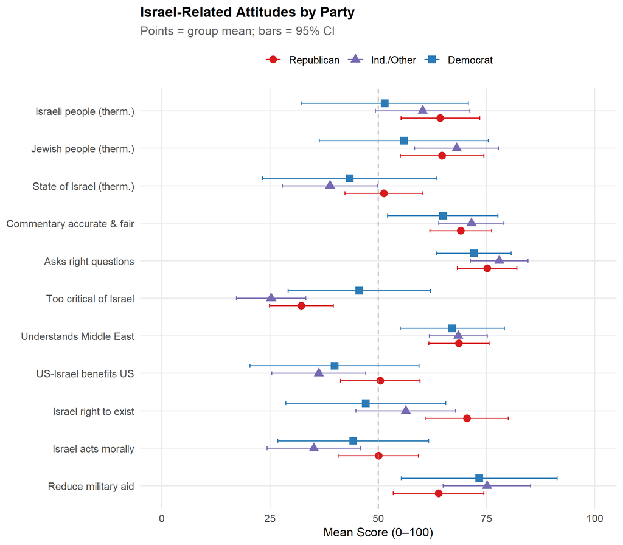

Figure 12: Mean Israel-related attitude scores by party affiliation (0–100 scales)

Table 14: Mean Israel-related attitude scores by party (0–100)

Israel-Related Attitudes by Party (0–100)

| Group | n | Israeli people (therm.) | Jewish people (therm.) | State of Israel (therm.) | Commentary accurate & fair | Asks right questions | Too critical of Israel | Understands Middle East | US-Israel benefits US | Israel right to exist | Israel acts morally | Reduce military aid |
| --- | --- | --- | --- | --- | --- | --- | --- | --- | --- | --- | --- | --- |
| Democrat | 10 | 51.5 | 55.9 | 43.4 | 64.9 | 72.1 | 45.6 | 67.1 | 39.9 | 47.1 | 44.2 | 73.3 |
| Ind./Other | 40 | 60.2 | 68.1 | 38.9 | 71.5 | 77.9 | 25.2 | 68.5 | 36.3 | 56.3 | 35.1 | 75.1 |
| Republican | 41 | 64.3 | 64.7 | 51.3 | 69.0 | 75.1 | 32.3 | 68.6 | 50.5 | 70.5 | 50.1 | 63.9 |

All scales 0–100.

Table 15: One-way ANOVA: party differences on each Israel attitude item

One-Way ANOVA: Party Group Differences

| Item | F stat | df (between) | df (within) | p |
| --- | --- | --- | --- | --- |
| Israeli people (therm.) | 0.66 | 2 | 88 | 0.521 |
| Jewish people (therm.) | 0.61 | 2 | 88 | 0.545 |
| State of Israel (therm.) | 1.50 | 2 | 88 | 0.230 |
| Commentary accurate & fair | 0.34 | 2 | 88 | 0.711 |
| Asks right questions | 0.37 | 2 | 88 | 0.694 |
| Too critical of Israel | 2.78 | 2 | 88 | 0.068 † |
| Understands Middle East | 0.02 | 2 | 88 | 0.980 |
| US-Israel benefits US | 1.99 | 2 | 88 | 0.143 |
| Israel right to exist | 2.84 | 2 | 88 | 0.064 † |
| Israel acts morally | 2.24 | 2 | 88 | 0.112 |
| Reduce military aid | 1.22 | 2 | 88 | 0.301 |

† p<.10, * p<.05, ** p<.01, *** p<.001.

## 9.2 Israel Attitudes by Political Ideology

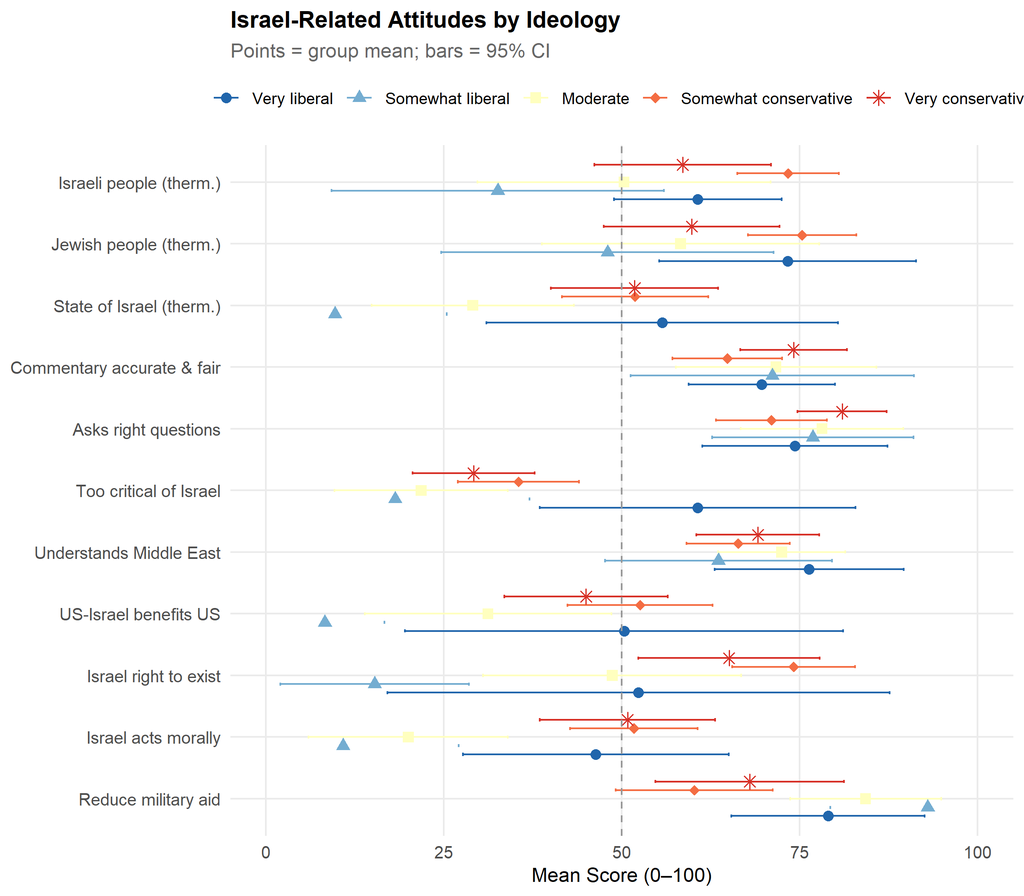

Figure 13: Mean Israel-related scores by ideology (ordered from liberal to conservative)

Table 16: Pearson correlations: ideology (1=Very liberal → 5=Very conservative) with Israel attitudes

Ideology–Attitude Correlations (ideology coded 1=Very liberal → 5=Very conservative)

| Item | r | p | n |
| --- | --- | --- | --- |
| Israeli people (therm.) | 0.16 | 0.129 | 91 |
| Jewish people (therm.) | 0.04 | 0.724 | 91 |
| State of Israel (therm.) | 0.27 | 0.009 ** | 91 |
| Commentary accurate & fair | 0.04 | 0.722 | 91 |
| Asks right questions | 0.06 | 0.570 | 91 |
| Too critical of Israel | 0.00 | 0.979 | 91 |
| Understands Middle East | -0.02 | 0.844 | 91 |
| US-Israel benefits US | 0.21 | 0.044 * | 91 |
| Israel right to exist | 0.32 | 0.002 ** | 91 |
| Israel acts morally | 0.33 | 0.002 ** | 91 |
| Reduce military aid | -0.22 | 0.039 * | 91 |

Positive r = more conservative ideology associated with higher score. † p<.10, * p<.05, ** p<.01, *** p<.001.

## 9.3 Israel Attitudes by Viewing Frequency

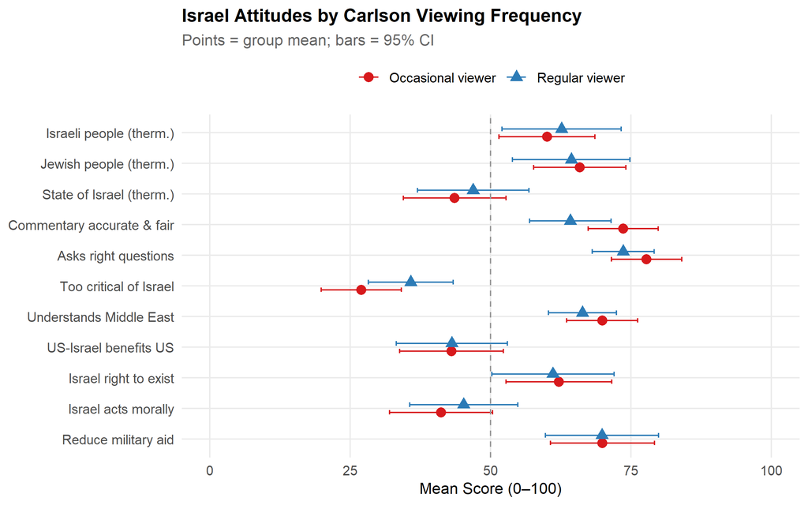

Figure 14: Mean Israel-related scores: regular vs. occasional Tucker Carlson viewers

## 9.4 Correlations with Age

Table 17: Pearson correlations: age with Israel-related attitudes

Age–Attitude Correlations

| Item | r | p | n |
| --- | --- | --- | --- |
| Israeli people (therm.) | 0.20 | 0.062 † | 91 |
| Jewish people (therm.) | 0.11 | 0.290 | 91 |
| State of Israel (therm.) | 0.16 | 0.130 | 91 |
| Commentary accurate & fair | -0.01 | 0.888 | 91 |
| Asks right questions | -0.01 | 0.941 | 91 |
| Too critical of Israel | -0.07 | 0.481 | 91 |
| Understands Middle East | -0.05 | 0.645 | 91 |
| US-Israel benefits US | 0.05 | 0.632 | 91 |
| Israel right to exist | 0.10 | 0.324 | 91 |
| Israel acts morally | 0.14 | 0.176 | 91 |
| Reduce military aid | -0.18 | 0.091 † | 91 |

Positive r = older respondents score higher. † p<.10, * p<.05, ** p<.01, *** p<.001.

## 9.5 Multivariate Regression

OLS regression predicting each Israel attitude from party, ideology, age, and race simultaneously. Reference category: Republican (party), Very conservative (ideology), White (race).

Table 18: OLS regression coefficients: demographic predictors of Israel attitudes

OLS Regression: Demographic Predictors (ref: Republican, Very conservative, White)

| Item | Party (ref = Republican) Ind./Other | Party (ref = Republican) Democrat | Ideology (ref = Very conservative) Smwt. lib. | Ideology (ref = Very conservative) Moderate | Ideology (ref = Very conservative) Smwt. con. | Age | Non-White | R2 |
| --- | --- | --- | --- | --- | --- | --- | --- | --- |
| Israeli people (therm.) | 4.7 | 1.8 | -28.8 | -14.5 | 9.4 | 0.37 † | -5.6 | 0.18 |
| Jewish people (therm.) | 8.2 | -5.2 | -24 | -24.8 | -6.3 | 0.2 | -17.6 * | 0.17 |
| State of Israel (therm.) | -1.8 | 8.9 | -36.5 | -16.2 | 2.8 | 0.32 | -9.2 | 0.20 |
| Commentary accurate & fair | 1.6 | -8.4 | -1.5 | -6.4 | -12.6 | -0.04 | -4.3 | 0.05 |
| Asks right questions | 2.9 | -5.5 | -2.9 | -4.5 | -9.4 | -0.03 | 1.3 | 0.05 |
| Too critical of Israel | -2.9 | 14.3 | -31.6 | -20.9 | -9.8 | -0.07 | -1.2 | 0.13 |
| Understands Middle East | -2 | -5.1 | -12.5 | -5.7 | -13.1 | -0.07 | -2.8 | 0.03 |
| US-Israel benefits US | -6.1 | 2.7 | -35.8 | -10.5 | 6.6 | 0.07 | -2.8 | 0.15 |
| Israel right to exist | -2.5 | -2.1 | -38.9 | -5.2 | 19.1 | 0.14 | 2.2 | 0.23 |
| Israel acts morally | -1.7 | 15 | -21.9 | -9.4 | 18.2 | 0.28 | -9.9 | 0.25 |
| Reduce military aid | 2.8 | -10 | 4.9 | -6.2 | -26.3 | -0.35 | 6.7 | 0.14 |

Coefficients = unstandardized B. † p<.10, * p<.05, ** p<.01, *** p<.001. n per model ≈ 85–91.

# 10 Change Score Analysis

This section examines *who* changes and *how much* in response to the AI conversation. Four questions are addressed:

1. **What do the change score distributions look like?** (histograms)
2. **Do the baseline attitude clusters differ in how much they change?**
3. **Which demographic characteristics predict change?**
4. **Are there distinct change-pattern clusters?** (independent k-means on Δ scores)

## 10.1 Distributions of Change Scores

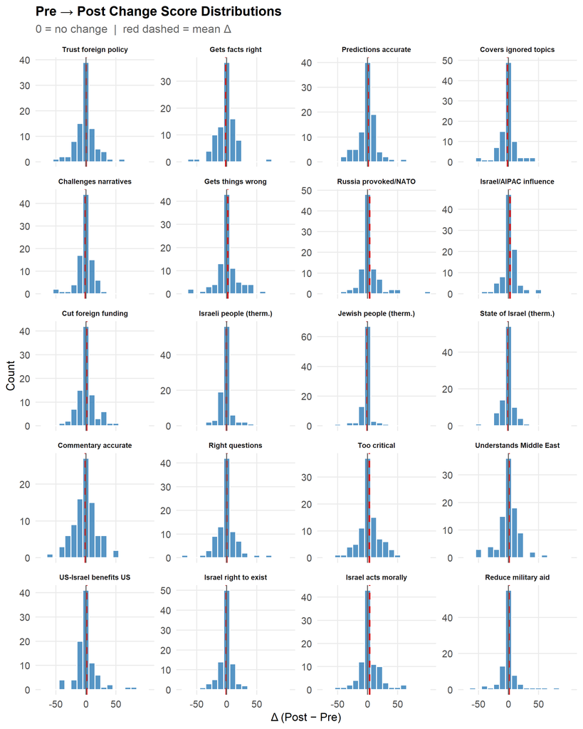

Figure 15: Distribution of pre-to-post change scores (Δ = post − pre) for all 20 outcome items

Table 19: Change score summary statistics for all outcome items

| Domain | Item | n | Mean Δ | SD | % Δ > 0 | % Δ < 0 |
| --- | --- | --- | --- | --- | --- | --- |
| Carlson Credibility | Trust foreign policy | 91 | 0.0 | 16.6 | 44% | 46% |
|  | Gets facts right | 91 | -1.7 | 15.7 | 40% | 47% |
|  | Predictions accurate | 91 | 0.8 | 14.9 | 54% | 33% |
|  | Covers ignored topics | 91 | -1.6 | 14.0 | 35% | 41% |
|  | Challenges narratives | 91 | -1.0 | 13.2 | 37% | 47% |
|  | Gets things wrong | 91 | 1.5 | 18.6 | 40% | 43% |
| Foreign Policy | Russia provoked/NATO | 91 | 3.1 | 17.5 | 38% | 37% |
|  | Israel/AIPAC influence | 91 | 2.3 | 12.9 | 43% | 33% |
|  | Cut foreign funding | 91 | 1.1 | 14.6 | 40% | 42% |
| Feeling Thermometers | Israeli people (therm.) | 91 | -0.7 | 9.7 | 31% | 40% |
|  | Jewish people (therm.) | 91 | -1.1 | 9.5 | 35% | 33% |
|  | State of Israel (therm.) | 91 | -0.8 | 9.9 | 34% | 34% |
| Carlson on Israel | Commentary accurate | 91 | -0.8 | 19.6 | 47% | 48% |
|  | Right questions | 91 | 0.0 | 17.0 | 46% | 41% |
|  | Too critical | 91 | 2.8 | 17.3 | 46% | 33% |
|  | Understands Middle East | 91 | 0.9 | 17.1 | 48% | 36% |
| Israel Policy | US-Israel benefits US | 91 | 0.9 | 17.7 | 34% | 41% |
|  | Israel right to exist | 91 | -1.0 | 11.0 | 29% | 36% |
|  | Israel acts morally | 91 | 3.0 | 17.3 | 40% | 35% |
|  | Reduce military aid | 91 | 0.8 | 17.5 | 29% | 40% |

% Δ > 0 = proportion who increased; % Δ < 0 = proportion who decreased.

## 10.2 Baseline Clusters and Change

Do participants in different *baseline* attitude clusters (Section 7) respond differently to the AI conversation?

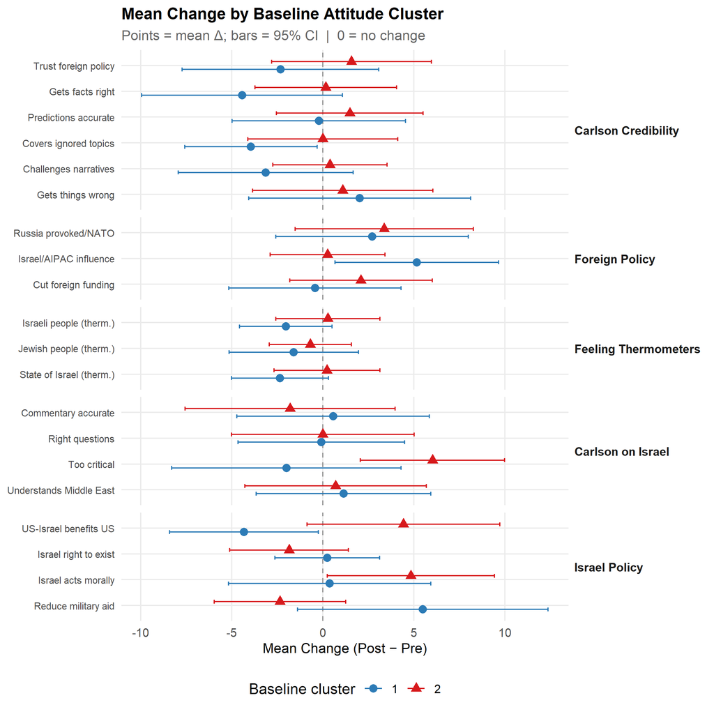

Figure 16: Mean change score by baseline attitude cluster and outcome item

Table 20: Does baseline cluster predict magnitude of change? One-way ANOVA per item.

ANOVA: Baseline cluster × change score

| Item | Domain | F | p |
| --- | --- | --- | --- |
| Trust foreign policy | Carlson Credibility | 1.22 | 0.273 |
| Gets facts right |  | 1.90 | 0.172 |
| Predictions accurate |  | 0.28 | 0.596 |
| Covers ignored topics |  | 1.77 | 0.187 |
| Challenges narratives |  | 1.58 | 0.211 |
| Gets things wrong |  | 0.05 | 0.815 |
| Russia provoked/NATO | Foreign Policy | 0.03 | 0.859 |
| Israel/AIPAC influence |  | 3.26 | 0.075 † |
| Cut foreign funding |  | 0.65 | 0.422 |
| Israeli people (therm.) | Feeling Thermometers | 1.24 | 0.268 |
| Jewish people (therm.) |  | 0.20 | 0.658 |
| State of Israel (therm.) |  | 1.48 | 0.227 |
| Commentary accurate | Carlson on Israel | 0.32 | 0.575 |
| Right questions |  | 0.00 | 0.982 |
| Too critical |  | 4.95 | 0.029 * |
| Understands Middle East |  | 0.01 | 0.907 |
| US-Israel benefits US | Israel Policy | 5.61 | 0.020 * |
| Israel right to exist |  | 0.80 | 0.374 |
| Israel acts morally |  | 1.47 | 0.229 |
| Reduce military aid |  | 4.60 | 0.035 * |

† p<.10, * p<.05, ** p<.01, *** p<.001.

## 10.3 Demographic Predictors of Change

OLS regressions with Δ (change score) as the outcome and party, ideology, age, and race as predictors.

Table 21: OLS regression: demographic predictors of change scores (ref: Republican, Very conservative, White)

OLS Δ Regressions (ref: Republican, Very conservative, White)

| Item | Domain | Party (ref=Rep.) Ind./Other | Party (ref=Rep.) Democrat | Ideology (ref=Very con.) Moderate | Ideology (ref=Very con.) Smwt.lib. | Age | Non-White | R2 |
| --- | --- | --- | --- | --- | --- | --- | --- | --- |
| Trust foreign policy | Carlson Credibility | 2.1 | -0.4 | 0.1 | -1.6 | -0.2 † | -5 | 0.07 |
| Gets facts right |  | -0.4 | -6.9 | -0.1 | 3.2 | -0.2 | -2.4 | 0.09 |
| Predictions accurate |  | 4.2 | -6.9 | -2.5 | 4.8 | -0.3 * | -3 | 0.14 |
| Covers ignored topics |  | 2 | -2.2 | -8.2 † | 4.8 | -0.2 * | -8.9 * | 0.16 |
| Challenges narratives |  | 1.7 | 4.6 | -1.2 | 14.1 ** | -0.3 *** | -12 *** | 0.38 |
| Gets things wrong |  | 1.7 | 20 * | 3.3 | -10.8 | 0 | 1 | 0.09 |
| Russia provoked/NATO | Foreign Policy | 1.4 | 9.2 | -4 | 7.4 | 0 | -1.8 | 0.08 |
| Israel/AIPAC influence |  | -0.6 | 4.4 | -7.1 | -3.4 | 0 | -2.6 | 0.07 |
| Cut foreign funding |  | -1.6 | 3.4 | 5.1 | -2.6 | 0 | -4.9 | 0.08 |
| Israeli people (therm.) | Feeling Thermometers | 2.5 | 9.9 * | 3.4 | -1.4 | -0.1 | -4.7 † | 0.14 |
| Jewish people (therm.) |  | -0.6 | 10.7 * | 1.2 | -5.6 | -0.1 | 1.2 | 0.12 |
| State of Israel (therm.) |  | 0.9 | 2.9 | -4.8 | -4.6 | 0 | 3.6 | 0.08 |
| Commentary accurate | Carlson on Israel | -3.5 | -10.6 | -2.4 | 11.5 | -0.2 | -2.9 | 0.06 |
| Right questions |  | -3.6 | -7.2 | 1.1 | 14.6 † | -0.1 | -8.5 † | 0.09 |
| Too critical |  | 1.3 | 2.7 | 2.2 | 5.7 | 0.3 ** | 1.8 | 0.11 |
| Understands Middle East |  | -1.6 | -6.2 | -7.4 | 13.8 † | -0.1 | -6.9 | 0.13 |
| US-Israel benefits US | Israel Policy | -1 | 10.6 | 16.7 ** | 8.8 | -0.1 | -2.8 | 0.20 |
| Israel right to exist |  | -0.9 | 9.6 † | 1.9 | 5.9 | 0 | -2.3 | 0.12 |
| Israel acts morally |  | -1 | 2 | 11.5 † | 0.4 | 0 | 1.5 | 0.06 |
| Reduce military aid |  | -2.2 | 14.5 † | -8.1 | -6.2 | 0 | -3.4 | 0.13 |

Coefficients = unstandardized B. † p<.10, * p<.05, ** p<.01, *** p<.001.

## 10.4 Cluster Analysis on Change Scores

Independent k-means clustering on the 20 change score variables identifies **distinct change-pattern profiles** — groups of participants who changed in similar ways (or didn’t change) across the outcome battery.

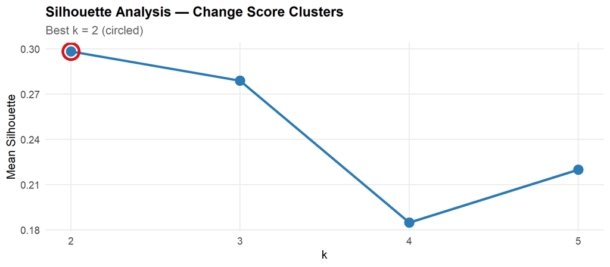

Figure 17: Silhouette scores for change-score clustering

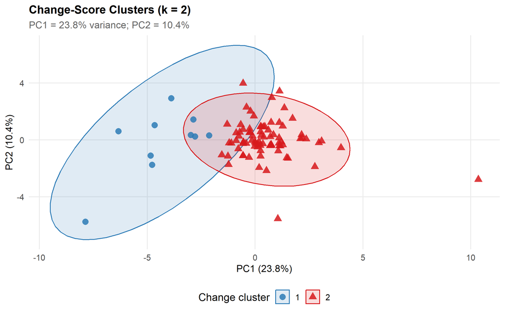

Figure 18: Change-score clusters projected onto first two principal components

Table 22: Mean change score (Δ) by change cluster

Mean Δ by Change Cluster (k = 2)

| Domain | Item | Cluster 1 (n=10) | Cluster 2 (n=81) |
| --- | --- | --- | --- |
| Carlson Credibility | Trust foreign policy | -26.6 | 3.3 |
|  | Gets facts right | -19.3 | 0.5 |
|  | Predictions accurate | -20.4 | 3.4 |
|  | Covers ignored topics | -17.8 | 0.4 |
|  | Challenges narratives | -18.0 | 1.0 |
|  | Gets things wrong | 24.3 | -1.3 |
| Foreign Policy | Russia provoked/NATO | 14.1 | 1.7 |
|  | Israel/AIPAC influence | -7.6 | 3.5 |
|  | Cut foreign funding | -6.1 | 2.0 |
| Feeling Thermometers | Israeli people (therm.) | 2.3 | -1.0 |
|  | Jewish people (therm.) | 3.8 | -1.7 |
|  | State of Israel (therm.) | -0.3 | -0.9 |
| Carlson on Israel | Commentary accurate | -26.8 | 2.4 |
|  | Right questions | -18.9 | 2.3 |
|  | Too critical | 5.9 | 2.4 |
|  | Understands Middle East | -28.8 | 4.5 |
| Israel Policy | US-Israel benefits US | 2.8 | 0.6 |
|  | Israel right to exist | 4.1 | -1.6 |
|  | Israel acts morally | 5.7 | 2.7 |
|  | Reduce military aid | -18.5 | 3.2 |

Δ = post − pre. Negative = decreased; positive = increased.

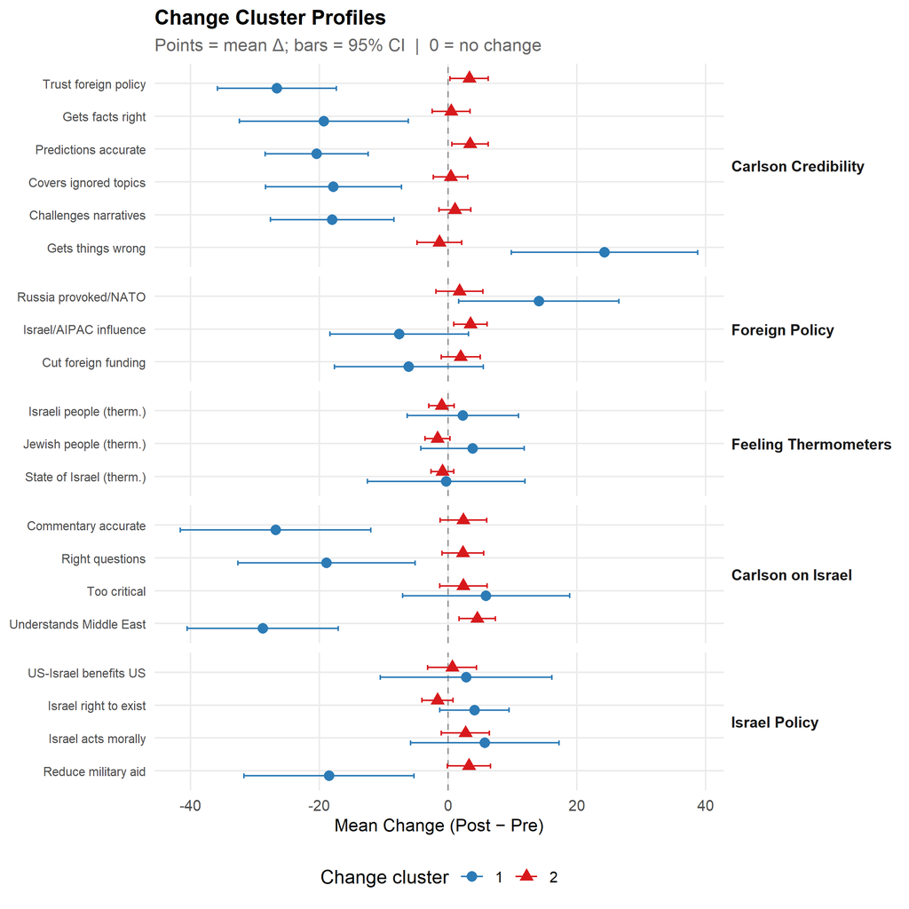

Figure 19: Change cluster mean profiles across all 20 outcome items

Table 23: Cross-tabulation: baseline attitude clusters × change-score clusters

Cross-tab: Baseline Attitude Clusters × Change-Score Clusters

| Baseline cluster | Change cl. 1 | Change cl. 2 |
| --- | --- | --- |
| 1 | 4 | 33 |
| 2 | 6 | 48 |

Cell values = n. Check for non-random associations between baseline position and change pattern.

Table 24: Demographic composition of change-score clusters

Demographic Profile of Change Clusters

| Change Cluster | n | % Republican | % Democrat | % Very/Smwt. Conservative | Mean Age |
| --- | --- | --- | --- | --- | --- |
| 1 | 10 | 50% | 20% | 60% | 50 |
| 2 | 81 | 44% | 10% | 74% | 40 |

# 11 Key Findings

Table 25: Summary of principal quantitative findings — Connect sample

[output not shown]

# Appendix: Technical Notes

**Data source:** CloudResearch Connect panel; participants pre-screened as Tucker Carlson viewers.

**Demographic variables:** Age, sex, gender, race, ethnicity, education, party, and income are panel-provided by Connect at the time of recruitment. Political ideology was asked in-survey (Q29).

**Question numbering:** Post-treatment batteries are Q17–Q21 in Connect (vs. Q18–Q22 in PrimePanels). Post-conversation reflections are Q22–Q23 (vs. Q23–Q24 in PrimePanels).

**Statistical tests:** Paired two-sided t-tests on row-matched pre/post observations. Effect size reported as Cohen’s *d* (mean difference / SD of differences). All p-values are two-sided.

**Clustering:** K-means (25 random starts, 100 max iterations); missing values median-imputed; variables scaled 0–1; optimal k by mean silhouette score.